# Question

A transformed square-root function, $f(x)$, and line, $L(x)$, are parameterized and graphed below.

$$f(x)=a\sqrt{n(x-h)}+k$$

$$L(x)=mx+b$$
The parameters:
$$\begin{aligned}
a &= \text{vertical flip and stretch} \\
n &= \text{horizontal flip and stretch} \\
h &= \text{horizontal translation} \\
k &= \text{vertical translation} \\
m &= \text{slope} \\
b &= \text{y-intercept}
\end{aligned}$$

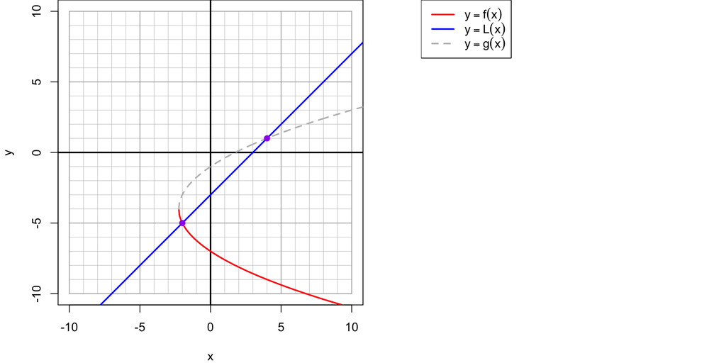

Notice, another transformed square-root function, $g(x)$, is also graphed above. It represents the other half of the parabola.

$$g(x)=-a\sqrt{n(x-h)}+k$$

Now, consider algebraically solving for values of $x_{i}$ that satisfy the equation $f(x_i)=L(x_i)$. Let $x_1$ and $x_2$ represent the two possible solutions such that $x_1<x_2$. Find both possible solutions (by inspecting the graph) and determine whether each is valid or extraneous.

- $x_1=$ ##ANSWER1##
- $x_1$ is ##ANSWER2## solution.
- $x_2=$ ##ANSWER3##
- $x_2$ is ##ANSWER4## solution.

## Answerlist

- -10
- -9
- -8
- -7
- -6
- -5
- -4
- -3
- -2
- -1
- 0
- 1
- 2
- 3
- 4
- 5
- 6
- 7
- 8
- 9
- 10
- an extraneous
- a valid
- -10
- -9
- -8
- -7
- -6
- -5
- -4
- -3
- -2
- -1
- 0
- 1
- 2
- 3
- 4
- 5
- 6
- 7
- 8
- 9
- 10
- an extraneous
- a valid

# Solution

Just read off the two $x$ values of the two purple points. The point further left is at point $(x_1,L(x_1))$ and the point further right is at point $(x_2,L(x_2))$. That way $x_1<x_2$, as required in the problem statement.

If the purple dot is on the red $y=f(x)$ curve, then the possible solution is a valid solution. If the purple dot is on the dashed-grey $y=g(x)$ curve, then the possible solution is extraneous. Lastly, if the purple dot is at the vertex of the parabol, then the solution is also valid.

So, in this case:

$$\begin{aligned}
x_1 &= -2 \\
x_1 &\text{ is a valid solution} \\
x_2 &= 4 \\
x_2 &\text{ is an extraneous solution}
\end{aligned}$$

# Meta-information

extype: cloze exclozetype: schoice|schoice|schoice|schoice exsolution: 000000001000000000000|01|000000000000001000000|10 exname: w_2val_1val_0val